# Week_06_weekend_homework

### MVP 1.1

#### Question 1

```r
library(tidyverse)
library(infer)
data(msleep)
```

```r
glimpse(msleep)
```

```
Rows: 83
Columns: 11
$ name         <chr> "Cheetah", "Owl monkey", "Mountain beaver", "Greater sh…
$ genus        <chr> "Acinonyx", "Aotus", "Aplodontia", "Blarina", "Bos", "B…
$ vore         <chr> "carni", "omni", "herbi", "omni", "herbi", "herbi", "ca…
$ order        <chr> "Carnivora", "Primates", "Rodentia", "Soricomorpha", "A…
$ conservation <chr> "lc", NA, "nt", "lc", "domesticated", NA, "vu", NA, "do…
$ sleep_total  <dbl> 12.1, 17.0, 14.4, 14.9, 4.0, 14.4, 8.7, 7.0, 10.1, 3.0,…
$ sleep_rem    <dbl> NA, 1.8, 2.4, 2.3, 0.7, 2.2, 1.4, NA, 2.9, NA, 0.6, 0.8…
$ sleep_cycle  <dbl> NA, NA, NA, 0.1333333, 0.6666667, 0.7666667, 0.3833333,…
$ awake        <dbl> 11.9, 7.0, 9.6, 9.1, 20.0, 9.6, 15.3, 17.0, 13.9, 21.0,…
$ brainwt      <dbl> NA, 0.01550, NA, 0.00029, 0.42300, NA, NA, NA, 0.07000,…
$ bodywt       <dbl> 50.000, 0.480, 1.350, 0.019, 600.000, 3.850, 20.490, 0.…
```

#### Question 2

1. Null hypothesis

Testing whether the mean sleep for all animals in the sampled population is significantly different from that of jabberwockies which is, on average, 7 hours a night.

H0: mean_sleep(animals) = 7 H1: mean_sleep(animals) != 7

alpha = 0.05

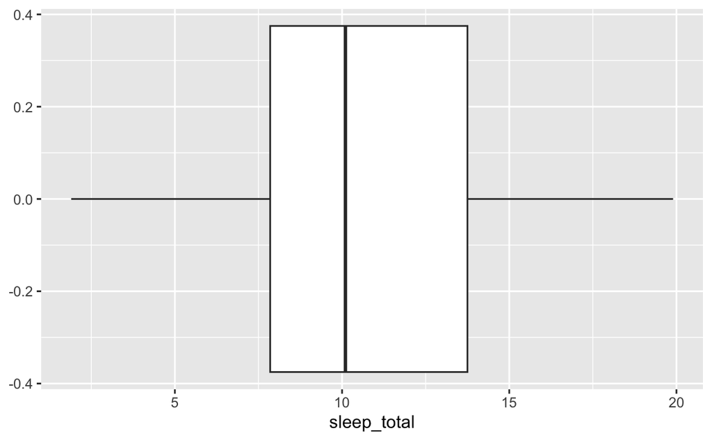

```r
# visualise the sleep data for sampled population
msleep %>%
  ggplot() +
  aes(x = sleep_total) +
  geom_boxplot()
```

The mean for all animals in the sample would appear to be just above 10 so it’s unlikely that mean sleep will be the same for all animals as per jabberwockies.

2. Observed statistic

```r
observed_stat <- msleep %>%
  summarise(mean_sleep = mean(sleep_total))

observed_stat
```

| mean_sleep |
| --- |
| 10.43373 |

3. Null distribution

```r
null_distribution <- msleep %>%
  specify(response = sleep_total) %>%
  hypothesise(null = "point", mu = 7) %>%
  generate(reps = 5000, type = "bootstrap") %>%
  calculate(stat = "mean")
```

4. Visualise null distribution with observed stat

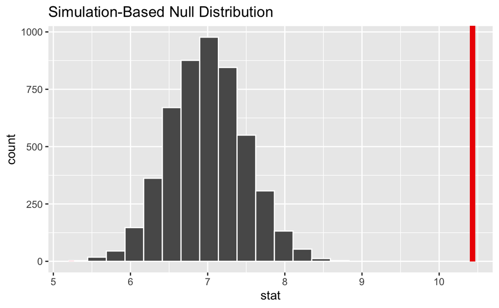

```r
null_distribution %>%
  visualise() +
  shade_p_value(obs_stat = observed_stat, direction = "both")
```

5. Calculate p-value

```r
null_distribution %>%
  get_p_value(obs_stat = observed_stat, direction = "both")
```

| p_value |
| --- |
| 0 |

6. Conclusions

A p-value trending towards zero, and less than the significance level of 0.05, means that we can reject the null hypothesis. There is sufficient evidence in the sampled population to indicate that the average sleep of animals differs significantly from that of jabberwockies.

#### Question 3.

1. Null hypothesis

H0: mean_sleep(omnivores) - mean_sleep(herbivores) = 0 H1: mean_sleep(omnivores) - mean_sleep(herbivores) > 0

alpha = 0.05

2. Observed statistic

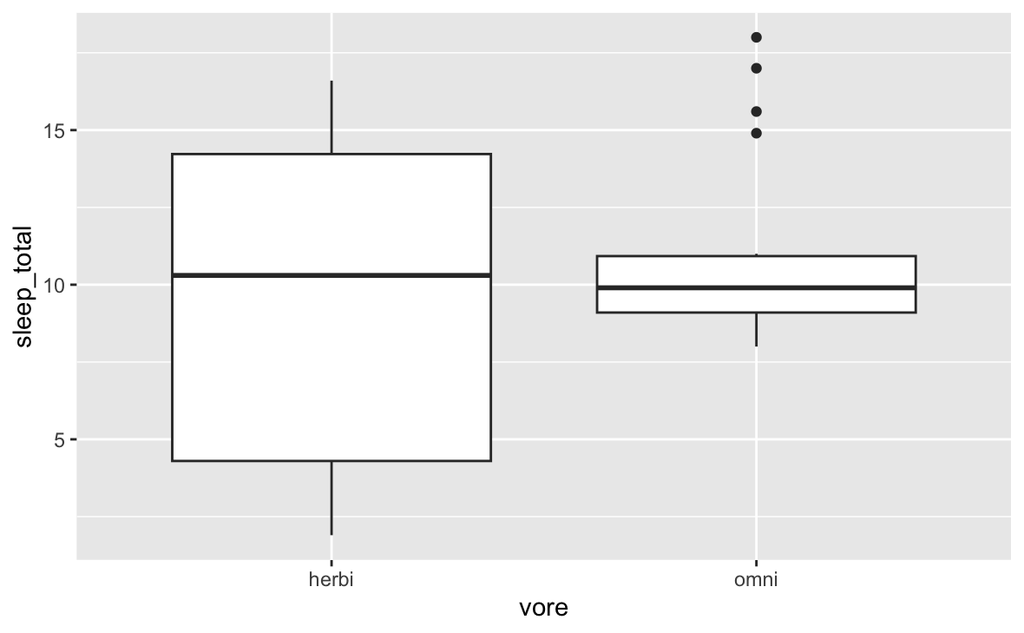

```r
# visualise mean sleep for omni and herbi -vores
msleep %>%
  filter(!is.na(vore)) %>%  # remove NAs
  filter(vore == "omni" | vore == "herbi") %>% # focus on omnivore or herbivore
  ggplot() +
  aes(x = vore, y = sleep_total) +
  geom_boxplot()
```

```r
msleep_tidy_vores <- msleep %>%
  filter(!is.na(vore)) %>%  # remove NAs
  filter(vore == "omni" | vore == "herbi") %>% # focus on omnivore or herbivore
  select(vore, sleep_total)

observed_stat <- msleep_tidy_vores %>%
  group_by(vore) %>%
  summarise(mean_sleep = mean(sleep_total)) %>%
  pivot_wider(names_from = vore, values_from = mean_sleep) %>%
  mutate(mean_sleep_diff = omni - herbi)

observed_stat$mean_sleep_diff
```

```
[1] 1.415625
```

3. Null distribution

```r
# difference of means from two independent samples = permute
null_distribution <- msleep_tidy_vores %>%
  specify(sleep_total ~ vore) %>%
  hypothesise(null = "independence") %>%
  generate(reps = 5000, type = "permute") %>%
  calculate(stat = "diff in means", order = c("omni", "herbi"))

head(null_distribution)
```

```
Response: sleep_total (numeric)
Explanatory: vore (factor)
Null Hypothesis: independence
```

| replicate | stat |
| --- | --- |
| 1 | 1.748750 |
| 2 | 1.058125 |
| 3 | 1.765000 |
| 4 | 0.050625 |
| 5 | -1.363125 |
| 6 | -0.770000 |

4. Visualise null distribution

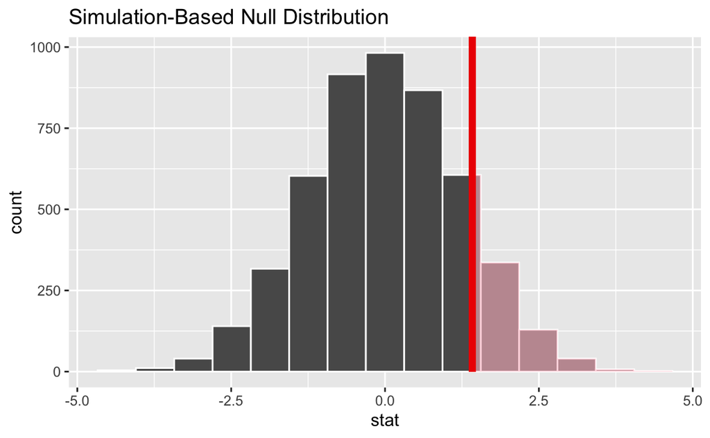

```r
null_distribution %>%
  visualise() +
  shade_p_value(obs_stat = observed_stat$mean_sleep_diff, direction = "right")
```

5. Calculate p-value

```r
null_distribution %>%
  get_p_value(obs_stat = observed_stat$mean_sleep_diff, direction = "right")
```

| p_value |
| --- |
| 0.1258 |

6. Conclusion

Out p-value is higher than our significance level of 0.05 so we may not reject the null hypothesis. There is insufficient evidence to show that omnivores sleep for significantly longer than herbivores on average.

#### Question 4.

1. Null hypothesis and significance level

H0: proportion of domestic animals in sample pop = 0.05 H1: proportion of domestic animals in sample pop > 0.05

alpha = 0.05

2. Observed statistic

```r
msleep_tidy_conservation <- msleep %>%
  filter(!is.na(conservation)) %>%
  mutate(is_domesticated = if_else(conservation == "domesticated", "yes", "no"))

observed_stat <- msleep_tidy_conservation %>%
  group_by(conservation) %>%
  summarise(prop = n() / nrow(msleep_tidy_conservation)) %>%
  filter(conservation == "domesticated")

observed_stat
```

| conservation | prop |
| --- | --- |
| domesticated | 0.1851852 |

3. Null distribution

```r
null_distribution <- msleep_tidy_conservation %>%
  specify(response = is_domesticated, success = "yes") %>%
  hypothesise(null = "point", p = 0.05) %>%
  generate(reps = 5000, type = "draw") %>%
  calculate(stat = "prop")
```

4. Visualise null distribution with observed stat

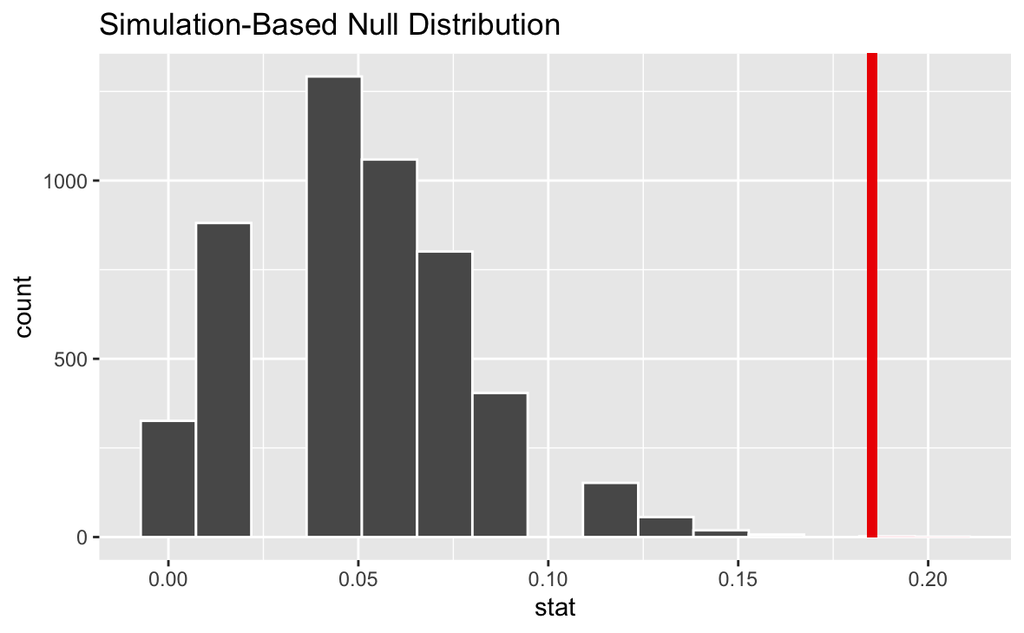

```r
null_distribution %>%
  visualise() +
  shade_p_value(obs_stat = observed_stat$prop, direction = "right")
```

5. Calculate p-values

```r
null_distribution %>%
  get_p_value(obs_stat = observed_stat$prop, direction = "right")
```

| p_value |
| --- |
| 6e-04 |

6. Conclusion

Since our p-value is less than our significance level of 0.05 we can reject the null hypothesis and conclude that the sampled population indicates that the proportion of domestic animals in the population is greater than 5%.

### MVP 1.2

#### Question 1.

Test = proportion Vs a fixed value

Is the proportion of town resident who know of the coffee shop greater than 40%?

H0: prop(residents who know of coffee shop) = 0.4 H1: prop(residents who know of coffee shop) > 0.4

Null distribution method = draw

#### Question 2.

Test = difference in proportions

Is the CTR of users higher when the banner is positioned at the top of the page?

H0: CTR rate(top of page) - CTR rate(RHS of page) = 0 H1: CTR rate(top of page) - CTR rate(RHS of page) > 0

Null distribution method = permute.

#### Question 3.

Test = mean Vs a fixed value

Is the mean width of parts different from a width of 145mm?

H0: mean_width(parts) = 145mm H1: mean_width(parts) != 145mm

Null distribution method = bootstrap

### MVP 1.3

#### Question 1.

As the p-value is higher (albeit only slightly) than the significance level, we are unable to reject the null hypothesis. There is insufficient evidence in the sampled population to indicate that more than 40% of residents know of the coffee shop.

#### Question 2.

With a p-value less than the very low significance level of 1% we can reject the null hypothesis that the CTR is independent of the location of the banner. Instead the sampled population indicates that the CTR when the banner is positioned at the top of the page is higher than when it is positioned at the RHS of the website page.

Question 3.

With a p-value that is higher than the significance level of 5%, we are unable to reject the null hypothesis that the mean width of parts manufactured is 145mm on average.